# Introduction to Python for statistics

### Stats 404, Winter 2018

# Outline

1) Introduction

- what is Python
- why use Python
- installation suggestions
- Python 2 vs. Python 3

2) Python basics

- data types
- syntax
- basic commands
- file reading/writing

3) Python packages for statistics & data science

- numpy
- matplotlib
- scipy
- pandas
- statsmodels
- scikit-learn

# Introduction

## What is Python?

Python is a general-purpose programming language. Like `R`, it is a high-level, object-oriented language. Unlike `R`, it was not developed specifically for the practice of statistics. However, a number of useful packages have been developed in Python for mathematics, statistics, and data science.

## Why use Python?

Having been developed in the computer science community, Python is used heavily for data science and machine learning. Some reasons you might use Python rather than `R`:

- You're interested in using a particular package in Python (e.g. pandas, scikit-learn)
- You want to integrate your code into a project (e.g. a website) that is already coded in Python
- Personal preference: you're more comfortable coding in Python (functionality, syntax)
- Your coworkers or collaborators are using Python

Disadvantages:

- Documentation isn't great compared to R (but still pretty good)
- Working with data can be a little clunky compared to R

My advice: give it a try and see if you like it!

## Anaconda

The Anaconda distribution of Python is an easy way to install Python along with the most useful packages. You can download it here: https://www.continuum.io/downloads

## Python 2.7 vs 3.6

There are two widely supported versions of Python. Apart from some slight differences in syntax (ex: whether the print function requires parentheses) the practical differences are small usually not important. I'm using Python 3 and would recommend doing the same unless you have some prior reason for doing otherwise (working with older python code, coworkers using Python 2, etc.)

### Note:

This presentation was prepared using Jupyter Notebook: http://jupyter.org

# The basics

## Comments

Like `R`, comments in Python use the `#` character.

```python
# This code does nothing.
```

## Variable names

You can include underscores and numbers in variable names, but not periods.

The period is saved for methods on objects.

Note: like R, no need to declare variable types.

```python
# no problem
my_var = 0
var0 = 0
```

```python
# problem
my.var = 0
```

```
---------------------------------------------------------------------------
NameError                                 Traceback (most recent call last)
<ipython-input-3-34465469c6e3> in <module>()
      1 # problem
----> 2 my.var = 0

NameError: name 'my' is not defined
```

## A brief note about methods

Explanation: Python is looking for a variable called `my` that has method `var`.

A method is a function that is saved as an attribute of an object and generally manipulates that object in some way.

## Declaring multiple variables

A little trick: you can declare or set multiple variables at once.

```python
x, y = 5, 10

print(x)
print(y)
```

```
5
10
```

## ints and floats

Like R, generally no need to declare the class of a number.

```python
x = 5
y = 2.75
z = 8 / 3

print(x,y,z)
```

```
5 2.75 2.6666666666666665
```

```python
print(type(x), type(y), type(z))
```

```
<class 'int'> <class 'float'> <class 'float'>
```

## Strings

Like `R`, strings can be defined using either single quotes '' or double quotes "".

`len()` returns the length of a string.

Concatenate strings using `+`.

```python
x = 'taco'

print(len(x))
```

```
4
```

```python
y = 'sauce'
z = x + ' ' + y

print(z)
```

```
taco sauce
```

Split a string using the `split()` method.

```python
z = z.split(' ')

print(z)
```

```
['taco', 'sauce']
```

You can also collapse a list of strings using `join`. (Note: `join` is a method of all strings.)

```python
x = ['One', 'two', 'red', 'blue']
x1 = ', '.join(x)

print(x1)
```

```
One, two, red, blue
```

## Tuples, lists, and dictionaries

The objects in square brackets above are *lists*.

Python has several different data types for combining multiple elements into a single object.

```python
# list
x = [1,2,3]

# tuple
y = (4,5,6)

# dictionary
z = {'a':7, 'b':8, 'c':9}
```

Why these different data structures?

- Lists are simple and relatively easy to work with.
- Tuples take up less memory than lists, but are immutable: once you've created one, you can't make any edits.
- Dictionaries allow for non-numeric indexing and are generally faster (faster searches and retrieval).

`len()` returns the length of these objects.

```python
print(len(x), len(y), len(z))
```

```
3 3 3
```

Note: `len()` also works for strings.

```python
len("apple")
```

```
5
```

Notably, these data structures can include any kind of object:

```python
mylist = [1,'taco',x,y,z]
mytuple = (1,'taco',x,y,z)
mydictionary = {0:1, 1:'taco', 2:x, 3:y, 4:z}

print(mylist)
print(mytuple)
print(mydictionary)
```

```
[1, 'taco', [1, 2, 3], (4, 5, 6), {'a': 7, 'b': 8, 'c': 9}]
(1, 'taco', [1, 2, 3], (4, 5, 6), {'a': 7, 'b': 8, 'c': 9})
{0: 1, 1: 'taco', 2: [1, 2, 3], 3: (4, 5, 6), 4: {'a': 7, 'b': 8, 'c': 9}}
```

A few useful methods of dictionaries:

```python
z = {'a':7, 'b':8, 'c':9}

list(z.keys())
```

```
['a', 'b', 'c']
```

```python
list(z.values())
```

```
[7, 8, 9]
```

```python
list(z.items())
```

```
[('a', 7), ('b', 8), ('c', 9)]
```

## Indexing

List and tuple elements (and substrings) can be accessed by index. Python starts indexes with 0, rather than 1.

Dictionary entries are accessed using the dictionary keys.

```python
# list
x = [1,2,3]

# tuple
y = (4,5,6)

# dictionary
z = {'a':7, 'b':8, 'c':9}

# string
s = "sasquatch"

# print an individual element of each object
print(x[0], y[2], z['a'], s[3])
```

```
1 6 7 q
```

Unlike R, negative indexes do not remove an element from a list.

Instead negative indexes go the other direction, e.g. `x[-1]` is the last entry in `x`, `x[-2]` is the second to last, etc.

```python
x = [1,2,3]

print(x[0],x[1],x[2])
print(x[-1],x[-2],x[-3])
```

```
1 2 3
3 2 1
```

## Slicing

Subset a list or tuple (or string) using square brackets and a colon. Think of the indexes as the walls separating different boxes. To return the contents of multiple boxes, you have to give the indexes of the outside walls.

```python
# Example:
x = [8,9,10]
```

```python
print("indexes:  0   1   2    3\nelements: | 8 | 9 | 10 |")
```

```
indexes:  0   1   2    3
elements: | 8 | 9 | 10 |
```

```python
print(x[0:2], x[1:3])
```

```
[8, 9] [9, 10]
```

Note that you can leave out the numbers on either side of the colon to extend the slice as far as possible.

```python
print(x[0:3], x[-3:], x[:])
```

```
[8, 9, 10] [8, 9, 10] [8, 9, 10]
```

Slicing also works with strings.

```python
s = "sasquatch"

print(s[0:6])
```

```
sasqua
```

Accessing non-consecutive elements is a little tricky. One way of doing so is by *list comprehension*, which I'll talk about more later.

```python
x = [2,4,6,8]

# take the subset corresponding to indexes 1 and 3
x_sub = [x[i] for i in [1,3]]
print(x_sub)
```

```
[4, 8]
```

## A note of caution: copying variables

When you set a variable equal to another variable, python saves space by pointing to the same object in memory. It does not create a unique copy of the object.

**If you edit the object, both variables will change.**

```python
# problem
x = [1,2,3]
y = x
y[0] = 10

print(x)
```

```
[10, 2, 3]
```

Safe ways of copying: slice it, use `list()`, or use the `copy()` method

```python
x = [1,2,3]

# make a copy by slicing x
a = x[:]

# make a copy using list()
b = list(x)

# make a copy using the x.copy() method
c = x.copy()

# make changes to the copies
a[0] = 10
b[1] = 20
c[2] = 30

print('x: ', x)
print('a: ', a)
print('b: ', b)
print('c: ', c)
```

```
x:  [1, 2, 3]
a:  [10, 2, 3]
b:  [1, 20, 3]
c:  [1, 2, 30]
```

## If statements

```python
x = 5

if (x > 10):
    print('x is greater than 10')
elif (x < 0):
    print('x is negative')
else:
    print('x is between 0 and 10')
```

```
x is between 0 and 10
```

If you like, you can put an if statement on a single line.

```python
y = 7

if y==7: print('y is seven!')
```

```
y is seven!
```

Note: booleans in Python are `True` and `False`. You can also use `0` and `1`.

```python
if True:
    print('yes')

if False:
    print('no')
```

```
yes
```

```python
if 1:
    print('yes')

if 0:
    print('no')
```

```
yes
```

## Loops

```python
x = ['apple','banana','cherry']

for fruit in x:
    print(fruit)
```

```
apple
banana
cherry
```

```python
for i in range(3):
    print(i)
```

```
0
1
2
```

```python
for a,b in [(1,1),(2,4),(3,9)]:
    print(a,'squared equals',b)
```

```
1 squared equals 1
2 squared equals 4
3 squared equals 9
```

```python
i = 10

while (i < 13):
    print(i)
    i+=1
```

```
10
11
12
```

## Functions

```python
def square(x):
    return(x**2)

print(square(4))
```

```
16
```

```python
# like R, you can give default parameter values
def prod(x=1,y=2):
    return(x*y)

print(prod(), prod(2), prod(3,4))
```

```
2 4 12
```

## Indentation

In Python, indentation is part of the syntax. If you fail to indent properly, it will return an error. This is particularly relevant for if statements, loops, and functions.

```python
if True:
print('true')
```

```
  File "<ipython-input-38-ce54c251ecbd>", line 2
    print('true')
        ^
IndentationError: expected an indented block
```

```python
for fruit in x:
print(fruit)
```

```
  File "<ipython-input-39-4a529fdc0120>", line 2
    print(fruit)
        ^
IndentationError: expected an indented block
```

```python
def square(x):
return(x**2)
```

```
  File "<ipython-input-40-3d5cef0cc8ea>", line 2
    return(x**2)
         ^
IndentationError: expected an indented block
```

## Basic operations on tuples and lists

For tuples and lists, the `+` operator performs concatenation and `*` performs repetition.

```python
x = [1,2,3]
y = [4,5,6]

print(x + y)
```

```
[1, 2, 3, 4, 5, 6]
```

```python
print(x * 3)
```

```
[1, 2, 3, 1, 2, 3, 1, 2, 3]
```

```python
# create a long list of zeros
x = [0] * 50

print(x)
```

```
[0, 0, 0, 0, 0, 0, 0, 0, 0, 0, 0, 0, 0, 0, 0, 0, 0, 0, 0, 0, 0, 0, 0, 0, 0, 0, 0, 0, 0, 0, 0, 0, 0, 0, 0, 0, 0, 0, 0, 0, 0, 0, 0, 0, 0, 0, 0, 0, 0, 0]
```

```python
# or an empty list
x = [None] * 10

print(x)
```

```
[None, None, None, None, None, None, None, None, None, None]
```

```python
# The following all cause errors:
x + 2
x - y
x / 2
```

```
---------------------------------------------------------------------------
TypeError                                 Traceback (most recent call last)
<ipython-input-45-845de10f1db6> in <module>()
      1 # The following all cause errors:
----> 2 x + 2
      3 x - y
      4 x / 2

TypeError: can only concatenate list (not "int") to list
```

```python
x = [2,3,1]
x.sort()

print(x)
```

```
[1, 2, 3]
```

## Manipulating lists and dictionaries

Python employs **list comprehension** and **dictionary comprehension** for creating and manipulating lists and dictionaries.

Recall that `range()` can be used to create a range of integers.

```python
x = range(4,12,2)

print(list(x))
```

```
[4, 6, 8, 10]
```

Great. But what if you want decimals? Or something more fancy?

```python
# decimals
x = [i/10 for i in range(10)]

print(x)
```

```
[0.0, 0.1, 0.2, 0.3, 0.4, 0.5, 0.6, 0.7, 0.8, 0.9]
```

```python
# a familiar sequence?
x = [(1/i) * (-1)**(i+1) for i in range(1,10)]

print(x)
```

```
[1.0, -0.5, 0.3333333333333333, -0.25, 0.2, -0.16666666666666666, 0.14285714285714285, -0.125, 0.1111111111111111]
```

This is also useful for manipulating an existing list. Suppose you want to apply a function to every number in a list:

```python
x = [3,2,6,4,12]
x_squared = [i**2 for i in x]

print(x_squared)
```

```
[9, 4, 36, 16, 144]
```

Or suppose you want to filter a list:

```python
y = [v for v in x if v > 5]

print(y)
```

```
[6, 12]
```

The same general idea also works for dictionaries.

You do have to use the `items()` method which essentially converts the dictionary to a list.

```python
x = {'a':4, 'b':7, 'c':10}

y = {k:v**2 for k,v in x.items()}

print(y)
```

```
{'a': 16, 'b': 49, 'c': 100}
```

## Reading and writing to files

In this regard, Python is quite similar to C.

```python
# create some data to write to file
x = [1,2,3,4,5]
squares = [i**2 for i in x]
colors = ['red','blue','yellow','green','red']

# convert x and squares to strings
x = [str(i) for i in x]
squares = [str(i) for i in squares]

print(x)
print(squares)
```

```
['1', '2', '3', '4', '5']
['1', '4', '9', '16', '25']
```

```python
# zip the three variables together
mydata = list(zip(x, squares, colors))
mydata
```

```
[('1', '1', 'red'),
 ('2', '4', 'blue'),
 ('3', '9', 'yellow'),
 ('4', '16', 'green'),
 ('5', '25', 'red')]
```

```python
# open a file for writing
f = open('testfile.csv','w')

# write one row at a time from mydata
# the for loop automatically pulls one element at a time (in this case one tuple at a time)
for row in mydata:
    f.write(','.join(row) + '\n')

# close the file
f.close()
```

Now to read the data back in:

```python
# look at the raw data
# think about how this can be parsed
f = open('testfile.csv', 'r')

f.read()
```

```
'1,1,red\n2,4,blue\n3,9,yellow\n4,16,green\n5,25,red\n'
```

```python
# read in the data
f = open('testfile.csv', 'r')

x2, squares2, colors2 = [], [], []
for line in f:
    # note: strip() takes out the \n
    tmp = line.strip().split(',')
    x2.append(tmp[0])
    squares2.append(tmp[1])
    colors2.append(tmp[2])

print(x2)
print(squares2)
print(colors2)
```

```
['1', '2', '3', '4', '5']
['1', '4', '9', '16', '25']
['red', 'blue', 'yellow', 'green', 'red']
```

```python
# convert the numeric strings to integers
x2 = [int(i) for i in x2]
squares2 = [int(i) for i in squares2]

print(x2)
print(squares2)
```

```
[1, 2, 3, 4, 5]
[1, 4, 9, 16, 25]
```

## View or set the working directory

```python
# import the os package. (More about packages next.)
import os

# view the working directory
os.getcwd()
```

```
'/Users/adamscherling/Documents/ucla/stat404/python'
```

```python
# change the working directory
os.chdir('/Users/adamscherling/Documents/ucla/stat404')
os.getcwd()
```

```
'/Users/adamscherling/Documents/ucla/stat404'
```

# The numpy package

`R` is designed so that everything is a vector, which is great for statistics. In Python, vectors do not come as naturally.

The `numpy` package makes life easier. It includes many useful tools for mathematics and statistics. For more information see http://www.numpy.org.

Packages are loaded in Python using `import`. It is common to specify an abbreviated name for loaded packages; these names help prevent mistakes if the same function is defined in multiple packages.

```python
# it's standard practice to use the np prefix for numpy
import numpy as np
```

## Arrays

Numpy arrays are convenient for representing vectors and matrices.

`np.arange` creates an array rather than a range object or list

```python
np.arange(10)
```

```
array([0, 1, 2, 3, 4, 5, 6, 7, 8, 9])
```

`np.arange` also allows non-integer step sizes

```python
np.arange(0,3,0.2)
```

```
array([ 0. ,  0.2,  0.4,  0.6,  0.8,  1. ,  1.2,  1.4,  1.6,  1.8,  2. ,
        2.2,  2.4,  2.6,  2.8])
```

The `linspace` command is also helpful:

```python
np.linspace(0,1,10)
```

```
array([ 0.        ,  0.11111111,  0.22222222,  0.33333333,  0.44444444,
        0.55555556,  0.66666667,  0.77777778,  0.88888889,  1.        ])
```

Unlike Python lists, array operations are elementwise.

```python
x = np.array([1,2,3])
y = np.array([4,5,6])

print(x + y)
```

```
[5 7 9]
```

```python
print(x**2)
```

```
[1 4 9]
```

Arrays can be reshaped to use as matrices.

```python
x = np.array([1,2,2,4,3,6]).reshape(3,2)

print(x)
```

```
[[1 2]
 [2 4]
 [3 6]]
```

Special types of matrices can be created easily.

```python
np.zeros([3,2])
```

```
array([[ 0.,  0.],
       [ 0.,  0.],
       [ 0.,  0.]])
```

```python
np.ones([2,3])
```

```
array([[ 1.,  1.,  1.],
       [ 1.,  1.,  1.]])
```

```python
np.diag([1,2,3])
```

```
array([[1, 0, 0],
       [0, 2, 0],
       [0, 0, 3]])
```

You still have to be careful about making copies.

```python
x = np.arange(5)
y = x
y[0] = 17

print(x)
```

```
[17  1  2  3  4]
```

```python
x = np.arange(5)
y = x.copy()
y[0] = 17

print(x)
print(y)
```

```
[0 1 2 3 4]
[17  1  2  3  4]
```

## Concatenate matrices and arrays

```python
# note the use of chain syntax; it's often useful to chain commands together
x = np.array([1,2,2,4,3,6,4,8]).reshape(4,2)

print(x)
```

```
[[1 2]
 [2 4]
 [3 6]
 [4 8]]
```

To concatenate arrays, the dimensions must align. Even for one-dimensional vectors you have to be explicit about the shape.

```python
y = np.array([3,6,9,12])
x = np.concatenate([x,y],axis=1)
```

```
---------------------------------------------------------------------------
ValueError                                Traceback (most recent call last)
<ipython-input-74-2564b3f87d13> in <module>()
      1 y = np.array([3,6,9,12])
----> 2 x = np.concatenate([x,y],axis=1)

ValueError: all the input arrays must have same number of dimensions
```

```python
y = np.array([3,6,9,12]).reshape(4,1)
x = np.concatenate([x,y],axis=1)

print(x)
```

```
[[ 1  2  3]
 [ 2  4  6]
 [ 3  6  9]
 [ 4  8 12]]
```

```python
z = np.array([5,10,15]).reshape(1,3)
x = np.concatenate([x,z],axis=0)

print(x)
```

```
[[ 1  2  3]
 [ 2  4  6]
 [ 3  6  9]
 [ 4  8 12]
 [ 5 10 15]]
```

```python
x = np.concatenate([x,x,x], axis=1)
print(x)
```

```
[[ 1  2  3  1  2  3  1  2  3]
 [ 2  4  6  2  4  6  2  4  6]
 [ 3  6  9  3  6  9  3  6  9]
 [ 4  8 12  4  8 12  4  8 12]
 [ 5 10 15  5 10 15  5 10 15]]
```

## Matrix algebra

Matrix multiplication is a defined property of arrays

```python
x = np.array([1,2,2,4,3,6]).reshape(3,2)
y = np.array([1,1])

print('x: ', x, '\n')
print('y: ', y, '\n')
print(x.dot(y))

# note: x.dot(y) is equivalent to np.dot(x,y)
```

```
x:  [[1 2]
 [2 4]
 [3 6]]

y:  [1 1]

[3 6 9]
```

Transpose a matrix:

```python
x.T
```

```
array([[1, 2, 3],
       [2, 4, 6]])
```

Invert a matrix:

```python
x = np.arange(4).reshape(2,2)
print(x)
```

```
[[0 1]
 [2 3]]
```

```python
y = np.linalg.inv(x)
print(y)
```

```
[[-1.5  0.5]
 [ 1.   0. ]]
```

```python
print(np.dot(x,y))
```

```
[[ 1.  0.]
 [ 0.  1.]]
```

Find eigenvalues and eigenvectors:

```python
eig = np.linalg.eig(x)
val = eig[0]
vec = eig[1]

print(val, '\n')
print(vec)
```

```
[-0.56155281  3.56155281]

[[-0.87192821 -0.27032301]
 [ 0.48963374 -0.96276969]]
```

## Other useful numpy functions

```python
np.pi
```

```
3.141592653589793
```

```python
x = np.arange(3)

# note that these allow the input to be an array
y = np.exp(x)
z = np.log(y)

print(y.round(2))
print(z)
```

```
[ 1.    2.72  7.39]
[ 0.  1.  2.]
```

```python
x = np.linspace(0,2*np.pi,5)
y = np.sin(x)

print(x.round(2))
print(y.round(2))
```

```
[ 0.    1.57  3.14  4.71  6.28]
[ 0.  1.  0. -1. -0.]
```

# Plotting using matplotlib

Matplotlib is the standard plotting package in Python. For a tutorial see https://matplotlib.org/tutorials/introductory/pyplot.html#sphx-glr-tutorials-introductory-pyplot-py.

Other packages such as ggplot and seaborn are also available.

```python
import matplotlib.pyplot as plt
```

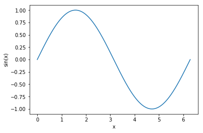

```python
x = np.linspace(0,2*np.pi,1000)
y = np.sin(x)

plt.plot(x,y)
plt.xlabel('x')
plt.ylabel('sin(x)')
plt.show()
```

# Random variables using the scipy package

`R` has built-in functionality for working with common probability distributions. In Python similar functions are available through the `stats` portion of the `scipy` package.

`scipy` has a lot more than just probability distributions; there are sub-libraries for topics such as linear algebra, optimization, Fourier transforms, signal processing, and more.

For more information about `scipy` see https://docs.scipy.org/doc/scipy/reference/.

```python
from scipy import stats
```

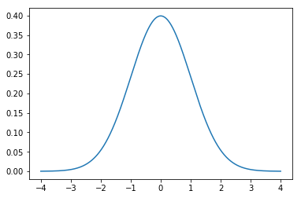

```python
# plot normal pdf
x = np.linspace(-4,4,1000)
y = stats.norm().pdf(x)

plt.plot(x,y)
plt.show()
```

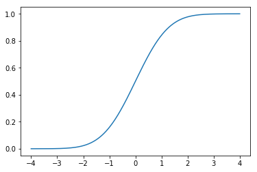

```python
# plot normal cdf
# (of course, you can also use this for Z tests, etc.)
x = np.linspace(-4,4,1000)
y = stats.norm().cdf(x)

plt.plot(x,y)
plt.show()
```

```python
# generate random variables from a distribution
# (note: you can also do this in numpy using np.random)
x = stats.norm(3,2).rvs(3)
y = stats.expon(4).rvs(4)
z = stats.poisson(1).rvs(5)

print(x.round(2))
print(y.round(2))
print(z)
```

```
[ 0.21  4.77  3.84]
[  4.07  11.07   4.6   12.06]
[0 0 0 1 2]
```

# The pandas package

The `pandas` package provides its own universe of special objects and functions for easily reading in and manipulating data, time series functionality, and other useful tools. In many ways `pandas` mimics R, but it also has some interesting tricks and tools of its own.

For more information see http://pandas.pydata.org/pandas-docs/stable/.

```python
import pandas as pd
```

## The `Series` object

`pandas` has its own answer to vectorizing Python: the `Series` object. These have an immense number of special attributes. See https://pandas.pydata.org/pandas-docs/stable/api.html#series.

They can also be easily converted into `numpy` arrays if you so choose.

```python
x = pd.Series(stats.norm().rvs(10))
print(x)
```

```
0    1.252194
1   -0.914974
2    2.317017
3    0.211160
4    0.235011
5   -1.285713
6    0.075007
7    0.126686
8   -0.453423
9   -0.738689
dtype: float64
```

```python
# some of the many available summary statistics
[x.min(), x.quantile(0.25), x.median(), x.quantile(0.75), x.max(), x.mean(), x.var(), x.autocorr()]
```

```
[-1.2857132036083179,
 -0.6673725452398099,
 0.10084687854416731,
 0.2290481375996089,
 2.3170173620705352,
 0.08242761805914933,
 1.1368443837056643,
 -0.30413002684341717]
```

```python
# find unique values
x.round().unique()
```

```
array([ 1., -1.,  2.,  0.])
```

```python
# filter
x.where(x > 0)
```

```
0    1.252194
1         NaN
2    2.317017
3    0.211160
4    0.235011
5         NaN
6    0.075007
7    0.126686
8         NaN
9         NaN
dtype: float64
```

```python
# filter and remove missing values
x.where(x > 0).dropna()
```

```
0    1.252194
2    2.317017
3    0.211160
4    0.235011
6    0.075007
7    0.126686
dtype: float64
```

As with `numpy` arrays, operations are elementwise.

```python
x + x
```

```
0    2.504387
1   -1.829948
2    4.634035
3    0.422320
4    0.470022
5   -2.571426
6    0.150015
7    0.253373
8   -0.906846
9   -1.477378
dtype: float64
```

```python
x ** 2
```

```
0    1.567989
1    0.837178
2    5.368569
3    0.044589
4    0.055230
5    1.653058
6    0.005626
7    0.016049
8    0.205592
9    0.545662
dtype: float64
```

Concatenate using `append`.

```python
x2 = x.append(x)
print(x2)
```

```
0    1.252194
1   -0.914974
2    2.317017
3    0.211160
4    0.235011
5   -1.285713
6    0.075007
7    0.126686
8   -0.453423
9   -0.738689
0    1.252194
1   -0.914974
2    2.317017
3    0.211160
4    0.235011
5   -1.285713
6    0.075007
7    0.126686
8   -0.453423
9   -0.738689
dtype: float64
```